# From a dipole to a rho amplitude

## A reproducible demonstration of the calculation after geometry

Notebook 1 audits nucleon sampling, hotspots, three-dimensional density, and thickness. This notebook starts from that interface and follows the current implementation to a **complex transverse photon–target amplitude for one event**:

$$ W_{\gamma N}\longrightarrow x \longrightarrow N(x,r),\,T_e(\mathbf b) \longrightarrow D_e(r,\mathbf b) \longrightarrow F_e(r,\boldsymbol\Delta) \longrightarrow \mathcal A_{T,e}(\boldsymbol\Delta). $$

The second branch is the photon–meson overlap: $$ \phi_T,\ \partial_s\phi_T \longrightarrow\Omega_T(r,z;Q) \longrightarrow H_T(r,q;Q). $$

Every production calculation below calls the current `upcmodel` functions. Notebook helpers arrange grids, plots, and independent checks. No geometry sampler, wavefunction, or scattering model is replaced by a notebook implementation.

**Jump to:** Energy and x · GBW · Nuclear profile · Wavefunctions · J0 · H integral · Fourier tests · Projected FFT · Complete amplitude · Phases · Energy scans · Event fluctuations · Convergence · Audit · Next step.

These are demonstrations of the implemented GBW + finite-A + Gaus-LC prescription. They are not a fit to data. The default is transverse rho photoproduction; nonzero `Q_GeV` checks still calculate the transverse component.

## 1. Reproducible setup and the meaning of every axis

Run all cells from the project directory or its `notebooks` directory. The setup reloads the model modules and uses independent deterministic random streams. The standard run saves every figure and a compact numerical snapshot.

The smooth baseline uses the paper's nucleon-profile variance $B_p$, while a hotspot uses $B_{\rm hs}$. Notebook 1 chose $B_p+B_{\rm hs}$ for its smooth comparison to the conditional hotspot mean. Those are different comparison prescriptions; here the choice is explicit and the current rho parameters are read from the repository.

```python
from pathlib import Path
from dataclasses import asdict
from html import escape
import hashlib
import importlib
import json
import platform
import sys
import time

import numpy as np
import scipy
from scipy.integrate import quad, cumulative_trapezoid
from scipy.special import j0, k0, k1
import matplotlib
import matplotlib.pyplot as plt
from matplotlib.colors import LogNorm, SymLogNorm
from matplotlib.ticker import NullFormatter
from IPython.display import HTML, Markdown, display

ROOT = next((p for p in (Path.cwd(), *Path.cwd().parents)
             if (p / "upcmodel" / "amplitudes.py").is_file()), None)
if ROOT is None:
    raise RuntimeError("Run from the asym_upc project or its notebooks directory.")
if str(ROOT) not in sys.path:
    sys.path.insert(0, str(ROOT))

import upcmodel.parameters as parameters_module
import upcmodel.densities as densities_module
import upcmodel.geometry as geometry_module
import upcmodel.fourier_transform as fourier_module
import upcmodel.amplitudes as amplitudes_module
import upcmodel.wavefunctions as wavefunctions_module
for module in (parameters_module, densities_module, geometry_module, fourier_module,
               amplitudes_module, wavefunctions_module):
    importlib.reload(module)

from upcmodel.parameters import HBARC_GEV_FM, E_EM, GBW_PAPER, RHO_HS, O16_ALPHA, O16_3PF
from upcmodel.geometry import (
    sample_3pf_events, sample_tetrahedron_nucleon_events,
    sample_target_hotspots, mean_hotspot_count, position_to_gaussian_thickness,
)
from upcmodel.fourier_transform import fourier_transform, fast_fourier_transform_1D
from upcmodel.amplitudes import (
    gbw_saturation_scale_squared, gbw_dipole_amplitude, nuclear_dipole_profile,
    dipole_profile_fourier_x, photon_target_amplitude_T,
)
from upcmodel.wavefunctions import (
    RHO_GAUS_LC_PARAM, N_C, gaus_lc_phi_T, gaus_lc_dphi_T_ds,
    gaus_lc_overlap_T, gaus_lc_overlap_integral_z,
)

SEED = 20260911
M_V_GEV = 0.776              # Fixed rho mass, KMW Table 1; distinct from m_f = 0.14.
W_GAMMAN_GEV = 40.0
Q_GEV = 0.0
N_Z = 64
N_R = 193
R_MIN_FM, R_MAX_FM = 0.001, 6.0
N_B = 192
B_PERIOD_FM = 24.0
POINT_CHUNK = 2048
N_EXAMPLE_EVENTS = 4         # Individual-event gallery, not an ensemble prediction.
SAVE_FIGURES = True

h = HBARC_GEV_FM
wf = RHO_GAUS_LC_PARAM
SIGMA_N_FM = np.sqrt(RHO_HS.B_p_fm2)
SIGMA_HS_FM = np.sqrt(RHO_HS.B_hs_fm2)
SIGMA0_FM2 = 4 * np.pi * RHO_HS.B_p_fm2
r_fm = np.geomspace(R_MIN_FM, R_MAX_FM, N_R)
OUTPUT_DIR = ROOT / "notebooks" / "amplitude_debug_outputs"
OUTPUT_DIR.mkdir(parents=True, exist_ok=True)
START_TIME = time.perf_counter()
CHECKS, FIGURE_PATHS = [], []
COLORS = {"WS / 3pF": "#246B8E", "alpha": "#C65D35"}
MODEL_NAMES = ("WS / 3pF", "alpha")
MODES = ("nucleon", "hotspot")
MODE_STYLES = {"nucleon": "-", "hotspot": "--"}

plt.rcParams.update({
    "figure.dpi": 110, "savefig.dpi": 155, "font.size": 10,
    "axes.titlesize": 12, "axes.labelsize": 10,
    "axes.spines.top": False, "axes.spines.right": False,
    "legend.frameon": False, "figure.facecolor": "white",
    "axes.facecolor": "white", "font.family": "DejaVu Sans",
})
get_ipython().run_line_magic("matplotlib", "inline")
print(f"Python {platform.python_version()} | NumPy {np.__version__} | SciPy {scipy.__version__}")
print(f"Seed {SEED}; {N_R} radii; {N_B} x {N_B} transverse points; {N_Z} z nodes.")
```

```
Python 3.14.6 | NumPy 2.5.2 | SciPy 1.18.1
Seed 20260911; 193 radii; 192 x 192 transverse points; 64 z nodes.
```

```python
# Presentation and independent numerical diagnostics.
def rng_for(stream):
    return np.random.default_rng(np.random.SeedSequence([SEED, stream]))

def table(headers, rows, caption=""):
    head = "".join(f"<th>{escape(str(v))}</th>" for v in headers)
    body = "".join("<tr>" + "".join(f"<td>{escape(str(v))}</td>" for v in row) + "</tr>"
                   for row in rows)
    display(HTML(
        "<style>.amplitude-table{border-collapse:collapse;margin:12px 0}"
        ".amplitude-table td,.amplitude-table th{padding:7px 12px;border-bottom:1px solid #d6dfe6;"
        "text-align:left}.amplitude-table th{background:#edf3f7}</style>"
        f"<p><strong>{escape(caption)}</strong></p><table class='amplitude-table'>"
        f"<thead><tr>{head}</tr></thead><tbody>{body}</tbody></table>"
    ))

def check(name, condition, detail):
    CHECKS.append({"name": name, "passed": bool(condition), "detail": str(detail)})
    if not condition:
        raise AssertionError(f"{name}: {detail}")

def finish(fig, name):
    path = OUTPUT_DIR / f"{len(FIGURE_PATHS)+1:02d}_{name}.png"
    if SAVE_FIGURES:
        fig.savefig(path, bbox_inches="tight")
        FIGURE_PATHS.append(path)
    plt.show()
    plt.close(fig)

def trap_weights(grid):
    widths = np.diff(grid)
    result = np.zeros(len(grid))
    result[:-1] += widths / 2
    result[1:] += widths / 2
    return result

def transverse_grid(n=N_B, period=B_PERIOD_FM):
    spacing = period / n
    axis = (np.arange(n) - n // 2) * spacing
    BX, BY = np.meshgrid(axis, axis, indexing="ij")
    return {"bx": axis, "by": axis.copy(), "points": np.column_stack((BX.ravel(), BY.ravel())),
            "shape": (n, n), "spacing": spacing, "period": period}

def area_weights(grid):
    # Match the production transform: rectangle in bx, trapezoid in by.
    return grid["spacing"] * np.tile(trap_weights(grid["by"]), len(grid["bx"]))

def thickness_on_grid(sources, grid):
    points = grid["points"]
    return np.concatenate([
        position_to_gaussian_thickness(points[i:i+POINT_CHUNK], sources["centers"],
                                       sources["sigma"], sources["weights"])
        for i in range(0, len(points), POINT_CHUNK)
    ])

def profile_on_grid(sources, radii, grid, bj_x):
    points = grid["points"]
    return np.concatenate([
        nuclear_dipole_profile(
            bj_x, radii, points[i:i+POINT_CHUNK], sources["centers"], GBW_PAPER,
            weights=sources["weights"], sigma_fm=sources["sigma"],
            sigma_0_fm2=SIGMA0_FM2, A=sources["A"],
        ) for i in range(0, len(points), POINT_CHUNK)
    ], axis=1)

def positive_bins(delta, maximum=1.0):
    return (delta >= 0) & (delta <= maximum)

def curve_style(key):
    return {"color": COLORS[key[0]], "ls": MODE_STYLES[key[1]],
            "label": f"{key[0]} / {key[1]}"}

GRID = transverse_grid()
table(["Quantity", "Array shape", "Units", "Meaning"], [
    ("x", "scalar", "1", "effective exclusive-production x"),
    ("N(x,r)", "(R,)", "1", "GBW dipole strength"),
    ("T_e(b)", "(P,)", "fm^-2", "target weight per transverse area; integral A"),
    ("D_e(r,b)", "(R,P)", "1", "d sigma_dip^A / d^2b; contains 2(1-S_A)"),
    ("Omega_T(r,z;Q)", "(R,Z)", "GeV^2", "photon-meson overlap"),
    ("F_e(r,Delta)", "(R,K)", "GeV^-2", "profile transform, without leading i"),
    ("H_T(r,q;Q)", "(R,K)", "GeV^2", "z integral including dipole-angle average"),
    ("A_T,e(Delta)", "(K,)", "GeV^-2", "complex event amplitude"),
], "R: dipole radii; P = Nx*Ny: transverse positions; K = Nx: full FFT momentum grid")
```

**R: dipole radii; P = Nx*Ny: transverse positions; K = Nx: full FFT momentum grid**

| Quantity | Array shape | Units | Meaning |
| --- | --- | --- | --- |
| x | scalar | 1 | effective exclusive-production x |
| N(x,r) | (R,) | 1 | GBW dipole strength |
| T_e(b) | (P,) | fm^-2 | target weight per transverse area; integral A |
| D_e(r,b) | (R,P) | 1 | d sigma_dip^A / d^2b; contains 2(1-S_A) |
| Omega_T(r,z;Q) | (R,Z) | GeV^2 | photon-meson overlap |
| F_e(r,Delta) | (R,K) | GeV^-2 | profile transform, without leading i |
| H_T(r,q;Q) | (R,K) | GeV^2 | z integral including dipole-angle average |
| A_T,e(Delta) | (K,) | GeV^-2 | complex event amplitude |

## 2. Where $W_{\gamma N}$ enters

$W_{\gamma N}$ is the photon–nucleon center-of-mass energy. We use the reference's effective exclusive-production variable $$x=\frac{Q^2+M_V^2}{Q^2+W_{\gamma N}^2},\qquad Q=0:\quad x=\frac{M_V^2}{W_{\gamma N}^2}.$$ This $x$ is the scalar called `bj_x` by the current code. The mass is the **meson mass**, not the wavefunction's effective quark mass. [Energy-dependent hotspot reference, Eq. (4)](https://arxiv.org/html/2312.11320v2#S2)

For the implementation, energy changes $Q_s^2(x)$ and the hotspot-count law. The overlap $H_T$ has no $W$ argument; at fixed $Q$, meson parameters, and grids it can be reused across energies and events.

The reference also discusses $x=(Q^2+M_V^2+|t|)/(Q^2+W^2)$. Here we use its usual $t$-independent approximation, keeping one fixed $x$ for the entire FFT. A $t$-dependent prescription would need an explicit extension of that calculation strategy. $q=\sqrt{|t|}$ and photon virtuality $Q$ are distinct. [Reference, discussion after Eq. (15)](https://arxiv.org/html/2312.11320v2#S4)

| Control | Value |
| --- | --- |
| W_gammaN | 40 GeV |
| Q | 0 GeV |
| M_rho | 0.776 GeV |
| x | 0.00037636 |
| Q0 | 1 GeV |
| x0; lambda | 0.0002; 0.21 |
| B_p; B_hs | 6.4; 0.8 GeV^-2 |
| sigma_0 = 4 pi B_p | 3.131575 fm^2 |
| sigma_nucleon; sigma_hotspot | 0.4992; 0.1765 fm |
| delta q; q_Nyquist magnitude | 0.0517; 4.9594 GeV |

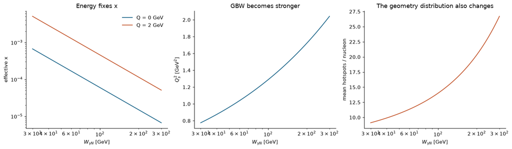

```python
def x_from_W(W_GeV, Q_GeV=0.0, meson_mass_GeV=M_V_GEV):
    # Notebook-level kinematic conversion, in the fixed-x approximation.
    W_GeV = np.asarray(W_GeV, dtype=float)
    if np.any(~np.isfinite(W_GeV)) or np.any(W_GeV <= meson_mass_GeV):
        raise ValueError("Use finite W above the meson mass in this illustrative conversion.")
    if not np.isfinite(Q_GeV) or Q_GeV < 0:
        raise ValueError("Q must be finite and nonnegative.")
    return (Q_GeV**2 + meson_mass_GeV**2) / (Q_GeV**2 + W_GeV**2)

BJ_X = float(x_from_W(W_GAMMAN_GEV, Q_GEV))
W_scan = np.geomspace(30, 300, 160)
x_scan = x_from_W(W_scan)
rates = mean_hotspot_count(x_scan, RHO_HS)
positive_count_means = rates / (-np.expm1(-rates))
table(["Control", "Value"], [
    ("W_gammaN", f"{W_GAMMAN_GEV:g} GeV"), ("Q", f"{Q_GEV:g} GeV"),
    ("M_rho", f"{M_V_GEV:g} GeV"), ("x", f"{BJ_X:.7g}"),
    ("Q0", f"{GBW_PAPER.Q0_GeV:g} GeV"),
    ("x0; lambda", f"{GBW_PAPER.x0:g}; {GBW_PAPER.lambda_gbw:g}"),
    ("B_p; B_hs", f"{RHO_HS.B_p_GeV_m2:g}; {RHO_HS.B_hs_GeV_m2:g} GeV^-2"),
    ("sigma_0 = 4 pi B_p", f"{SIGMA0_FM2:.6f} fm^2"),
    ("sigma_nucleon; sigma_hotspot", f"{SIGMA_N_FM:.4f}; {SIGMA_HS_FM:.4f} fm"),
    ("delta q; q_Nyquist magnitude", f"{2*np.pi*h/B_PERIOD_FM:.4f}; {np.pi*h/GRID['spacing']:.4f} GeV"),
])
check("W-to-x photoproduction limit",
      np.allclose(x_scan, M_V_GEV**2/W_scan**2, rtol=1e-15), "Uses meson mass and W squared")
check("Increasing W decreases x", np.all(np.diff(x_scan) < 0), "Fixed Q and meson mass")
fig, axes = plt.subplots(1, 3, figsize=(14, 4), layout="constrained")
for Q, color in [(0.0, "#246B8E"), (2.0, "#C65D35")]:
    axes[0].loglog(W_scan, x_from_W(W_scan, Q), color=color, label=f"Q = {Q:g} GeV")
axes[0].set(xlabel=r"$W_{\gamma N}$ [GeV]", ylabel="effective x", title="Energy fixes x")
axes[0].legend()
axes[1].semilogx(W_scan, gbw_saturation_scale_squared(x_scan), color="#246B8E")
axes[1].set(xlabel=r"$W_{\gamma N}$ [GeV]", ylabel=r"$Q_s^2$ [GeV$^2$]",
            title="GBW becomes stronger")
axes[2].semilogx(W_scan, positive_count_means, color="#C65D35")
axes[2].set(xlabel=r"$W_{\gamma N}$ [GeV]", ylabel="mean hotspots / nucleon",
            title="The geometry distribution also changes")
finish(fig, "energy_to_x")
```

## 3. GBW: one dipole size at a time

The code implements $$Q_s^2(x)=Q_0^2(x_0/x)^\lambda,\qquad N(x,r)=1-\exp[-(r/h)^2Q_s^2(x)/4],\quad h=\hbar c.$$ Thus $Q_0$ is in **GeV**, $Q_s^2$ in **GeV²**, and $N$ is dimensionless. The proton cross-section factor is $\sigma_0 N$. The small-radius limit is quadratic; at large radius $N$ tends to one. The reference's printed saturation-scale line has a notational inconsistency; the code and axes here explicitly use $Q_s^2$. [Model reference, Eq. (8) and parameter discussion](https://arxiv.org/html/2312.11320v2)

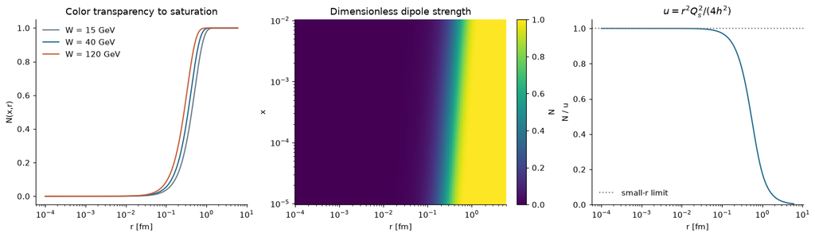

```python
r_display = np.geomspace(1e-4, 6, 320)
fig, axes = plt.subplots(1, 3, figsize=(14, 4), layout="constrained")
for W, color in zip([15, 40, 120], ["#6b7b8c", "#246B8E", "#C65D35"]):
    x_value = float(x_from_W(W))
    N_value = gbw_dipole_amplitude(x_value, r_display)
    axes[0].semilogx(r_display, N_value, color=color, label=f"W = {W} GeV")
axes[0].set(xlabel="r [fm]", ylabel="N(x,r)", title="Color transparency to saturation")
axes[0].legend()
x_image = np.geomspace(1e-5, 1e-2, 100)
N_image = np.array([gbw_dipole_amplitude(x, r_display) for x in x_image])
mesh = axes[1].pcolormesh(r_display, x_image, N_image, shading="auto",
                         vmin=0, vmax=1, cmap="viridis", rasterized=True)
axes[1].set(xscale="log", yscale="log", xlabel="r [fm]", ylabel="x", title="Dimensionless dipole strength")
fig.colorbar(mesh, ax=axes[1], label="N")
u = (r_display/h)**2 * gbw_saturation_scale_squared(BJ_X) / 4
axes[2].semilogx(r_display, gbw_dipole_amplitude(BJ_X, r_display)/u, color="#246B8E")
axes[2].axhline(1, color="gray", ls=":", label="small-r limit")
axes[2].set(xlabel="r [fm]", ylabel="N / u", title=r"$u=r^2 Q_s^2/(4h^2)$", ylim=(0,1.05))
axes[2].legend()
finish(fig, "gbw_strength")

Qs2 = float(gbw_saturation_scale_squared(BJ_X))
check("Q_s^2(x0) = Q0^2", np.isclose(gbw_saturation_scale_squared(GBW_PAPER.x0),
      GBW_PAPER.Q0_GeV**2), "Q0 is squared once")
check("GBW zero-size limit", gbw_dipole_amplitude(BJ_X, 0.0) == 0, "N(x,0) = 0 exactly")
check("GBW characteristic radius", np.isclose(gbw_dipole_amplitude(BJ_X, 2*h/np.sqrt(Qs2)),
      1-np.exp(-1), rtol=1e-14), "r = 2 h / Qs")
tiny_r = 1e-6
tiny_u = (tiny_r/h)**2 * Qs2/4
check("GBW small-r expansion", abs(gbw_dipole_amplitude(BJ_X,tiny_r)/tiny_u-1)<1e-10,
      "Independent leading-order expansion")
check("GBW saturation", gbw_dipole_amplitude(BJ_X,100.0)==1.0, "Large dipole limit")
```

## 4. Feed both event formats into the nuclear profile

We sample a few events for this notebook; the detailed geometry audit remains in notebook 1. All 16 nucleons participate in the target. For each hotspot event, sample once at the chosen $x$, then reuse the same centers and weights for every radius, impact point, and momentum.

The existing interface uses centers $(M,3)$, weights $(M,)$, and a Gaussian width. $A$ remains 16 even when $M$ is the number of hotspots. The finite-A prescription is $$ \kappa=\frac{\sigma_0 N(x,r)T_e(\mathbf b)}{2A},\qquad D_e=2[1-(1-\kappa)^A]. $$ The code requires $0\leq\kappa\leq1$, and $0\leq D_e\leq2$. This nonlinear response is why one should transform $D_e$ after constructing it. [Reference, Eq. (9)](https://arxiv.org/html/2312.11320v2#S2)

```python
EVENTS, PROTON_MASKS, CASES = {}, {}, {}
for stream, model, sampler, params in [
    (10, "WS / 3pF", sample_3pf_events, O16_3PF),
    (20, "alpha", sample_tetrahedron_nucleon_events, O16_ALPHA),
]:
    EVENTS[model], PROTON_MASKS[model] = sampler(N_EXAMPLE_EVENTS, params, rng_for(stream))
    nucleons = EVENTS[model][0]
    hs, parents, weights, counts = sample_target_hotspots(nucleons, BJ_X, RHO_HS, rng_for(stream+1))
    CASES[model, "nucleon"] = {"centers": nucleons, "weights": np.ones(params.A),
                              "sigma": SIGMA_N_FM, "A": params.A}
    CASES[model, "hotspot"] = {"centers": hs, "weights": weights,
                              "sigma": SIGMA_HS_FM, "A": params.A,
                              "parents": parents, "counts": counts}

T_MAPS = {key: thickness_on_grid(sources, GRID) for key, sources in CASES.items()}
rows = []
for key, sources in CASES.items():
    total = float(T_MAPS[key] @ area_weights(GRID))
    rows.append((*key, len(sources["centers"]), f"{sources['weights'].sum():.12g}",
                 f"{sources['sigma']:.4f}", f"{total:.8f}"))
    check(f"Source normalization: {key}", np.isclose(sources["weights"].sum(),16),
          "Weights retain the original A")
    check(f"Grid captures target weight: {key}", abs(total/16-1)<1e-5,
          f"integrated T = {total:.12g}; exact full-plane value 16")
table(["Geometry", "Mode", "M", "sum weights", "sigma [fm]", "grid integral T"], rows)
```

| Geometry | Mode | M | sum weights | sigma [fm] | grid integral T |
| --- | --- | --- | --- | --- | --- |
| WS / 3pF | nucleon | 16 | 16 | 0.4992 | 16.00000000 |
| WS / 3pF | hotspot | 158 | 16 | 0.1765 | 16.00000000 |
| alpha | nucleon | 16 | 16 | 0.4992 | 16.00000000 |
| alpha | hotspot | 167 | 16 | 0.1765 | 16.00000000 |

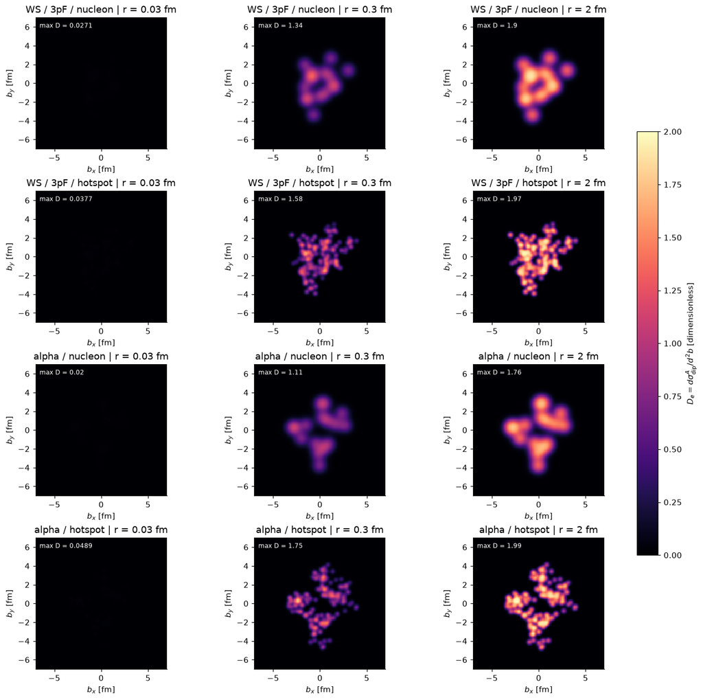

**Increasing r changes the interaction strength on the same target**

| Geometry | Mode | max kappa | max D |
| --- | --- | --- | --- |
| WS / 3pF | nucleon | 0.16905 | 1.89668 |
| WS / 3pF | hotspot | 0.23548 | 1.97276 |
| alpha | nucleon | 0.12448 | 1.76163 |
| alpha | hotspot | 0.30631 | 1.99425 |

```python
map_r = np.array([0.03, 0.3, 2.0])
D_MAPS, OPACITY_ROWS = {}, []
fig, axes = plt.subplots(4, 3, figsize=(13, 12), layout="constrained")
for row, (key, sources) in enumerate(CASES.items()):
    profiles = profile_on_grid(sources, map_r, GRID, BJ_X)
    D_MAPS[key] = profiles
    kappa = SIGMA0_FM2 * gbw_dipole_amplitude(BJ_X,map_r)[:,None] * T_MAPS[key][None,:] / 32
    OPACITY_ROWS.append((*key, f"{kappa.max():.5f}", f"{profiles.max():.5f}"))
    check(f"Finite-A range: {key}", np.all((profiles>=0)&(profiles<=2)), "0 <= D <= 2")
    for col, radius in enumerate(map_r):
        mesh = axes[row,col].pcolormesh(GRID["bx"],GRID["by"],
            profiles[col].reshape(GRID["shape"]).T, shading="auto",
            cmap="magma", vmin=0, vmax=2, rasterized=True)
        axes[row,col].set(xlim=(-7,7),ylim=(-7,7),aspect="equal",
                         xlabel=r"$b_x$ [fm]",ylabel=r"$b_y$ [fm]",
                         title=f"{key[0]} / {key[1]} | r = {radius:g} fm")
        axes[row,col].text(0.03,0.96,f"max D = {profiles[col].max():.3g}",
                           transform=axes[row,col].transAxes,va="top",color="white",fontsize=8)
fig.colorbar(mesh, ax=axes.ravel().tolist(), label=r"$D_e=d\sigma_{\rm dip}^A/d^2b$ [dimensionless]",
             shrink=0.65)
finish(fig, "nuclear_profile_maps")
table(["Geometry","Mode","max kappa","max D"], OPACITY_ROWS,
      "Increasing r changes the interaction strength on the same target")
```

### Screening and the dipole–nucleus cross section

Integrating $D_e$ over physical area gives a cross section in fm². In the weak-opacity limit, $D_e\simeq\sigma_0 N T_e$, so the area integral approaches $A\sigma_0 N$. The finite-A response screens this additive result. The small parameter for the linear approximation is the **total opacity** $\sigma_0 NT_e$, not merely the single-factor $\kappa$.

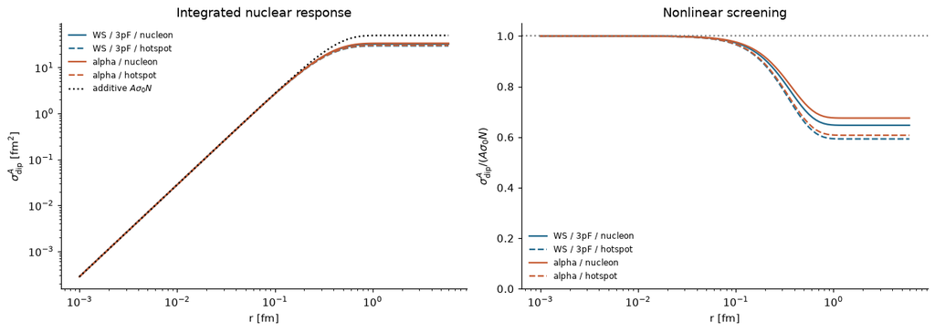

```python
profile_r = np.geomspace(0.001,6,100)
linear_cross_section = 16*SIGMA0_FM2*gbw_dipole_amplitude(BJ_X,profile_r)
fig, axes = plt.subplots(1,2,figsize=(12,4.2),layout="constrained")
for key,sources in CASES.items():
    profiles = profile_on_grid(sources,profile_r,GRID,BJ_X)
    integrated = profiles @ area_weights(GRID)
    axes[0].loglog(profile_r,integrated,**curve_style(key))
    axes[1].semilogx(profile_r,integrated/linear_cross_section,**curve_style(key))
    probe_r = 1e-5
    small = profile_on_grid(sources,[0.,probe_r],GRID,BJ_X)
    linear = SIGMA0_FM2*gbw_dipole_amplitude(BJ_X,probe_r)*T_MAPS[key]
    error = np.max(np.abs(small[1]-linear))/np.max(linear)
    check(f"Nuclear zero-r limit: {key}",np.all(small[0]==0),"D(x,0,b) = 0")
    check(f"Thin-target expansion: {key}",error<1e-7,f"peak-normalized error {error:.3e}")
axes[0].loglog(profile_r,linear_cross_section,color="black",ls=":",label=r"additive $A\sigma_0 N$")
axes[0].set(xlabel="r [fm]",ylabel=r"$\sigma_{\rm dip}^A$ [fm$^2$]",title="Integrated nuclear response")
axes[0].legend(fontsize=8)
axes[1].axhline(1,color="gray",ls=":")
axes[1].set(xlabel="r [fm]",ylabel=r"$\sigma_{\rm dip}^A/(A\sigma_0N)$",
            title="Nonlinear screening",ylim=(0,1.05))
axes[1].legend(fontsize=8)
finish(fig,"nuclear_screening")
```

## 5. Wavefunction and photon–meson overlap

The public radius is in fm; the wavefunction uses $s=r/h$ in GeV$^{-1}$. Your Gaus-LC functions implement $$ \phi_T=N_T[z(1-z)]^2e^{-s^2/(2R_T^2)},\qquad \partial_s\phi_T=-\frac{s}{R_T^2}\phi_T . $$ The derivative is with respect to $s$, not $r_{\rm fm}$. With $\epsilon^2=m_f^2+z(1-z)Q^2$, $$ \Omega_T=\frac{\widehat e_f eN_c}{\pi z(1-z)} \left[m_f^2K_0(\epsilon s)\phi_T- (z^2+(1-z)^2)\epsilon K_1(\epsilon s)\partial_s\phi_T\right]. $$ The code includes the flavor charge and electromagnetic coupling already. [Kowalski, Motyka and Watt, Eqs. (21), (29), Table 1](https://arxiv.org/pdf/hep-ph/0606272)

The plots compare positive interior $r,z$ values, as required by the overlap API. The raw overlap is not a probability distribution; the amplitude supplies its integration measure and scattering response.

| Wavefunction parameter | Value |
| --- | --- |
| m_f_GeV | 0.14 |
| N_T | 4.47 |
| R_T_Squared_GeV_m2 | 21.9 |
| eff_charge | 0.7071067811865475 |

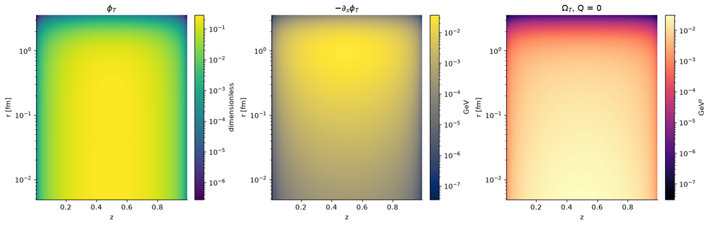

```python
z_plot = np.linspace(0.01,0.99,121)
r_plot = np.geomspace(0.005,3.5,160)
phi = gaus_lc_phi_T(wf,z_plot,r_plot)
derivative = gaus_lc_dphi_T_ds(wf,z_plot,r_plot)
overlap = gaus_lc_overlap_T(wf,z_plot,r_plot,Q_GeV=0.)
table(["Wavefunction parameter","Value"], [(name,value) for name,value in asdict(wf).items()])
fig,axes = plt.subplots(1,3,figsize=(14,4.4),layout="constrained")
for ax,values,title,label,cmap in [
    (axes[0],phi,r"$\phi_T$","dimensionless","viridis"),
    (axes[1],-derivative,r"$-\partial_s\phi_T$","GeV","cividis"),
    (axes[2],overlap,r"$\Omega_T$, Q = 0","GeV²","magma"),
]:
    mesh=ax.pcolormesh(z_plot,r_plot,values,shading="auto",cmap=cmap,
                       norm=LogNorm(vmin=max(values.max()*1e-6,1e-14),vmax=values.max()),
                       rasterized=True)
    ax.set(xlabel="z",ylabel="r [fm]",yscale="log",title=title)
    fig.colorbar(mesh,ax=ax,label=label)
finish(fig,"wavefunction_maps")

# Independent derivative check: perturb s by ds, then convert back to the public radius.
r_probe=np.geomspace(0.02,2.5,50)
z_probe=np.array([0.2,0.5,0.8])
ds=1e-5
finite_difference=(gaus_lc_phi_T(wf,z_probe,r_probe+h*ds)-
                   gaus_lc_phi_T(wf,z_probe,r_probe-h*ds))/(2*ds)
exact_derivative=gaus_lc_dphi_T_ds(wf,z_probe,r_probe)
derivative_error=np.max(np.abs(finite_difference-exact_derivative))/np.max(np.abs(exact_derivative))
check("Wavefunction derivative in GeV^-1 coordinate",derivative_error<1e-8,
      f"peak-normalized finite-difference error {derivative_error:.3e}")
check("Overlap z-exchange symmetry",np.allclose(
      gaus_lc_overlap_T(wf,z_probe,r_probe,Q_GeV=2),
      gaus_lc_overlap_T(wf,1-z_probe,r_probe,Q_GeV=2),rtol=1e-13),
      "z <-> 1-z at nonzero Q")
```

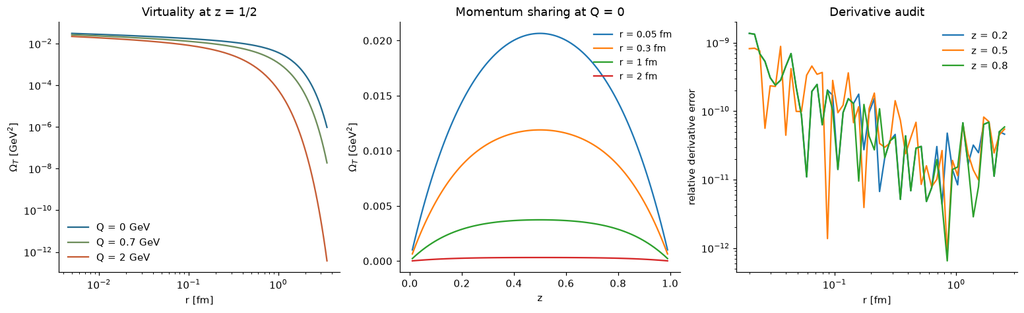

```python
fig,axes=plt.subplots(1,3,figsize=(14,4.2),layout="constrained")
for Q,color in zip([0.,0.7,2.],["#246B8E","#6e8d5b","#C65D35"]):
    values=gaus_lc_overlap_T(wf,[0.5],r_plot,Q_GeV=Q)[:,0]
    axes[0].loglog(r_plot,values,color=color,label=f"Q = {Q:g} GeV")
axes[0].set(xlabel="r [fm]",ylabel=r"$\Omega_T$ [GeV$^2$]",title="Virtuality at z = 1/2")
axes[0].legend()
for radius in [0.05,0.3,1.0,2.0]:
    values=gaus_lc_overlap_T(wf,z_plot,[radius],Q_GeV=0)[0]
    axes[1].plot(z_plot,values,label=f"r = {radius:g} fm")
axes[1].set(xlabel="z",ylabel=r"$\Omega_T$ [GeV$^2$]",title="Momentum sharing at Q = 0")
axes[1].legend(fontsize=9)
relative_derivative=np.abs((finite_difference-exact_derivative)/exact_derivative)
for j,z in enumerate(z_probe):
    axes[2].loglog(r_probe,np.maximum(relative_derivative[:,j],1e-16),label=f"z = {z:g}")
axes[2].set(xlabel="r [fm]",ylabel="relative derivative error",title="Derivative audit")
axes[2].legend()
finish(fig,"overlap_slices_and_derivative")
```

## 6. The dipole orientation produces $J_0$

With $\theta$ measured between $\mathbf r$ and $\boldsymbol\Delta$, the displacement phase is $e^{ia\cos\theta}$, where $a=(1/2-z)rq/h$. In the implemented model the overlap and dipole response depend on $r=|\mathbf r|$ without further dependence on its orientation. Therefore $$ \frac{1}{2\pi}\int_0^{2\pi}e^{ia\cos\theta}\,d\theta=J_0(a). $$ This is an **amplitude average**, not an average of absolute squares. It can oscillate and become negative. [Bessel integral identity](https://dlmf.nist.gov/10.9.E2)

The target remains an arbitrary two-dimensional event. Its structure stays in the impact-parameter Fourier transform. This dipole-angle integral does not circularize the target and does not describe the two UPC production pathways.

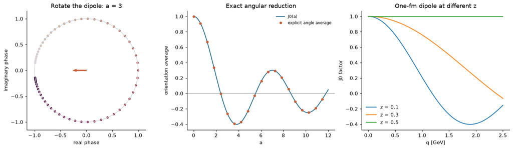

```python
theta=np.linspace(0,2*np.pi,2048,endpoint=False)
a_scan=np.linspace(0,12,160)
angular_average=np.exp(1j*a_scan[:,None]*np.cos(theta)[None,:]).mean(axis=1)
angular_error=np.max(np.abs(angular_average-j0(a_scan)))
check("Dipole-angle integral gives J0",angular_error<1e-13,
      f"max complex error from 2048 angles {angular_error:.3e}")
fig,axes=plt.subplots(1,3,figsize=(14,4),layout="constrained")
a_example=3.0
phasors=np.exp(1j*a_example*np.cos(theta[::16]))
axes[0].plot(np.cos(theta),np.sin(theta),color="#cbd2d8",lw=1)
axes[0].scatter(phasors.real,phasors.imag,c=theta[::16],cmap="twilight",s=12)
axes[0].arrow(0,0,float(j0(a_example)),0,width=0.015,color="#C65D35",
              length_includes_head=True)
axes[0].set(xlim=(-1.15,1.15),ylim=(-1.15,1.15),aspect="equal",
            xlabel="real phase",ylabel="imaginary phase",title="Rotate the dipole: a = 3")
axes[1].plot(a_scan,j0(a_scan),color="#246B8E",label="J0(a)")
axes[1].plot(a_scan[::8],angular_average.real[::8],"o",ms=4,color="#C65D35",
             label="explicit angle average")
axes[1].axhline(0,color="gray",lw=0.7)
axes[1].set(xlabel="a",ylabel="orientation average",title="Exact angular reduction")
axes[1].legend(fontsize=8)
q_demo=np.linspace(0,2.5,200)
for z in [0.1,0.3,0.5]:
    axes[2].plot(q_demo,j0((0.5-z)*1.0*q_demo/h),label=f"z = {z:g}")
axes[2].set(xlabel="q [GeV]",ylabel="J0 factor",title="One-fm dipole at different z")
axes[2].legend()
finish(fig,"dipole_angle_to_j0")
```

## 7. Complete the $z$ integral: $H_T$

Your new helper computes $$H_T(r,q;Q)=\int_0^1 dz\, \Omega_T(r,z;Q)\,J_0((1/2-z)rq/h).$$ Its array has shape $(R,K)$ and units GeV². It contains no target geometry, no factor $i$, no radial measure, and no overall $2\pi/(4\pi)$ factor.

Gauss–Legendre nodes avoid the endpoint evaluations, but their mapped weights cover all of $[0,1]$: $z_j=(u_j+1)/2,\ \widetilde w_j=w_j/2$. Taking a trapezoidal integral over only interior uniformly spaced nodes instead loses two intervals. The old method is included below solely as a diagnostic control. [NumPy quadrature convention](https://numpy.org/doc/stable/reference/generated/numpy.polynomial.legendre.leggauss.html)

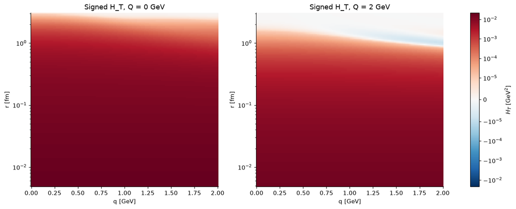

```python
r_H=np.geomspace(0.005,3.0,140)
q_H=np.linspace(0,2,141)
H_Q0=gaus_lc_overlap_integral_z(wf,r_H,q_H,Q_GeV=0,nz=N_Z)
H_Q2=gaus_lc_overlap_integral_z(wf,r_H,q_H,Q_GeV=2,nz=N_Z)
vmax=max(np.max(np.abs(H_Q0)),np.max(np.abs(H_Q2)))
norm=SymLogNorm(linthresh=1e-5,vmin=-vmax,vmax=vmax,base=10)
fig,axes=plt.subplots(1,2,figsize=(12,4.8),layout="constrained")
for ax,values,Q in zip(axes,[H_Q0,H_Q2],[0,2]):
    mesh=ax.pcolormesh(q_H,r_H,values,shading="auto",cmap="RdBu_r",norm=norm,rasterized=True)
    ax.set(xlabel="q [GeV]",ylabel="r [fm]",yscale="log",title=f"Signed H_T, Q = {Q} GeV")
fig.colorbar(mesh,ax=axes.tolist(),label=r"$H_T$ [GeV$^2$]")
finish(fig,"integrated_overlap_maps")
```

### Independent forward check and quadrature convergence

At $q=Q=0$, $J_0=1$ and $\epsilon=m_f$. The $z$ factors can be integrated analytically: $\int z(1-z)dz=1/6$ and $\int z(1-z)[z^2+(1-z)^2]dz=1/10$. Hence, for $s=r/h$, $$ H_T(r,0;0)=\frac{\widehat e_f eN_cN_T}{\pi}e^{-s^2/(2R_T^2)} \left[\frac{m_f^2K_0(m_fs)}6+\frac{m_fsK_1(m_fs)}{10R_T^2}\right]. $$ This checks normalization independently of any numerical $z$ integration. Nonzero-$Q,q$ values are compared to adaptive integration of the existing overlap.

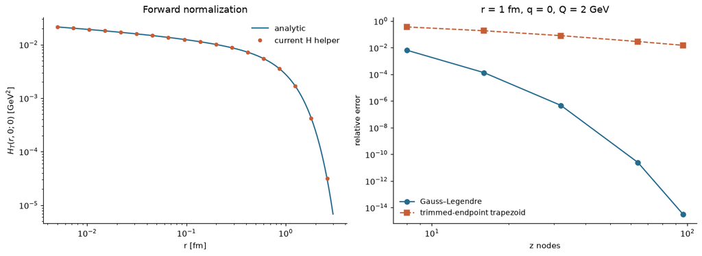

```python
def analytic_forward_H(radii):
    s=np.asarray(radii)/h
    return (wf.eff_charge*E_EM*N_C*wf.N_T/np.pi *
            np.exp(-s*s/(2*wf.R_T_Squared_GeV_m2)) *
            (wf.m_f_GeV**2*k0(wf.m_f_GeV*s)/6 +
             wf.m_f_GeV*s*k1(wf.m_f_GeV*s)/(10*wf.R_T_Squared_GeV_m2)))

def adaptive_H(radius,q,Q):
    return quad(lambda z: gaus_lc_overlap_T(wf,z,radius,Q_GeV=Q)[0,0] *
                j0((0.5-z)*radius*q/h),0,1,epsabs=1e-13,epsrel=1e-11,limit=200)[0]

H_forward=gaus_lc_overlap_integral_z(wf,r_H,[0.0],Q_GeV=0,nz=N_Z)[:,0]
H_exact=analytic_forward_H(r_H)
forward_error=np.max(np.abs(H_forward/H_exact-1))
check("Analytic H(r,0;0)",forward_error<1e-12,f"max relative error {forward_error:.3e}")
probe_r=np.array([0.05,0.2,0.5,1.0,2.0])
probe_q=np.array([0.0,0.3,1.0,2.0])
adaptive_errors=[]
for Q in [0.,0.7,2.]:
    computed=gaus_lc_overlap_integral_z(wf,probe_r,probe_q,Q_GeV=Q,nz=N_Z)
    reference=np.array([[adaptive_H(ri,qi,Q) for qi in probe_q] for ri in probe_r])
    error=np.max(np.abs(computed-reference))
    adaptive_errors.append(error)
    check(f"Adaptive H comparison, Q={Q:g}",error<1e-11,f"max absolute error {error:.3e} GeV^2")

node_counts=np.array([8,16,32,64,96])
reference=adaptive_H(1.0,0.0,2.0)
gauss_error,trimmed_error=[],[]
for n in node_counts:
    value=gaus_lc_overlap_integral_z(wf,[1.0],[0.0],Q_GeV=2,nz=int(n))[0,0]
    gauss_error.append(abs(value/reference-1))
    z_old=np.linspace(0,1,int(n)+2)[1:-1]
    trimmed=np.trapezoid(gaus_lc_overlap_T(wf,z_old,[1.0],Q_GeV=2)[0],x=z_old)
    trimmed_error.append(abs(trimmed/reference-1))
fig,axes=plt.subplots(1,2,figsize=(12,4.3),layout="constrained")
axes[0].loglog(r_H,H_exact,color="#246B8E",label="analytic")
axes[0].loglog(r_H[::8],H_forward[::8],"o",color="#C65D35",ms=4,label="current H helper")
axes[0].set(xlabel="r [fm]",ylabel=r"$H_T(r,0;0)$ [GeV$^2$]",title="Forward normalization")
axes[0].legend()
axes[1].loglog(node_counts,np.maximum(gauss_error,1e-16),"o-",color="#246B8E",label="Gauss–Legendre")
axes[1].loglog(node_counts,trimmed_error,"s--",color="#C65D35",label="trimmed-endpoint trapezoid")
axes[1].set(xlabel="z nodes",ylabel="relative error",title="r = 1 fm, q = 0, Q = 2 GeV")
axes[1].legend(fontsize=9)
finish(fig,"overlap_quadrature_audit")
```

## 8. Generic Fourier helpers: normalization, origin, and speed

The direct helper is a **numerical trapezoidal transform**, despite the informal description “analytic version” sometimes used during development. We compare both numerical helpers with a genuinely analytic Gaussian transform.

With the symmetric convention, $$f(x)=e^{-(x-a)^2/(2\sigma^2)} \quad\Rightarrow\quad \widehat f(k)=\sigma e^{-\sigma^2k^2/2}e^{-ika}.$$ The generic helper uses reciprocal units: fm for position gives fm$^{-1}$ for angular frequency. The physics wrapper later supplies $\Delta=hk$.

The FFT uses a rectangle sum with period $N\,dx$, while the direct helper uses trapezoids between the first and last sample. Their continuum answers agree when the omitted boundary contributions are negligible.

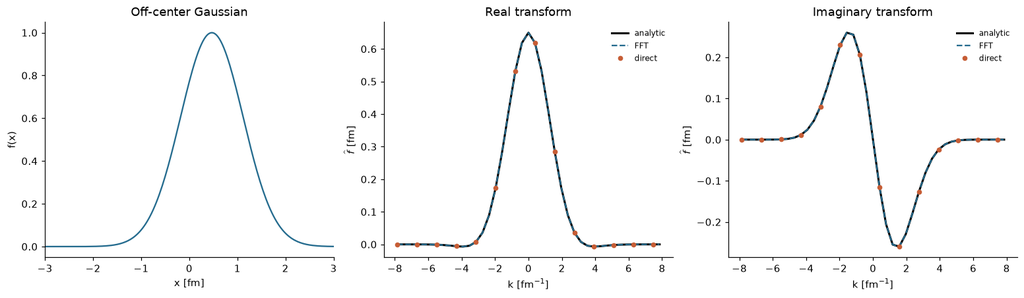

```python
x_test=-8.03+0.03125*np.arange(512)
sigma_test,center_test=0.65,0.47
f_test=np.exp(-(x_test-center_test)**2/(2*sigma_test**2))
fft_test,k_test=fast_fourier_transform_1D(f_test,x_test,angular=True)
analytic_test=sigma_test*np.exp(-sigma_test**2*k_test**2/2)*np.exp(-1j*k_test*center_test)
selected=np.flatnonzero(np.abs(k_test)<=8)
direct_test=fourier_transform(f_test,x_test,k_test[selected])
fft_error=np.max(np.abs(fft_test-analytic_test))
direct_error=np.max(np.abs(direct_test-analytic_test[selected]))
check("Generic FFT analytic Gaussian",fft_error<1e-11,f"max error {fft_error:.3e}")
check("Generic direct FT analytic Gaussian",direct_error<1e-11,f"max error {direct_error:.3e}")
cyclic,f_cyclic=fast_fourier_transform_1D(f_test,x_test,angular=False)
check("Angular/cyclic FFT conventions",
      np.allclose(k_test,2*np.pi*f_cyclic) and
      np.allclose(cyclic,np.sqrt(2*np.pi)*fft_test,rtol=1e-13,atol=1e-14),
      "2 pi in frequency; sqrt(2 pi) in normalization")

fig,axes=plt.subplots(1,3,figsize=(14,4),layout="constrained")
axes[0].plot(x_test,f_test,color="#246B8E")
axes[0].set(xlim=(-3,3),xlabel="x [fm]",ylabel="f(x)",title="Off-center Gaussian")
for ax,part,title in [(axes[1],np.real,"Real transform"),(axes[2],np.imag,"Imaginary transform")]:
    ax.plot(k_test[selected],part(analytic_test[selected]),color="black",lw=2,label="analytic")
    ax.plot(k_test[selected],part(fft_test[selected]),"--",color="#246B8E",label="FFT")
    ax.plot(k_test[selected][::3],part(direct_test)[::3],"o",ms=4,color="#C65D35",label="direct")
    ax.set(xlabel=r"k [fm$^{-1}$]",ylabel=r"$\widehat f$ [fm]",title=title)
    ax.legend(fontsize=8)
finish(fig,"generic_fourier_gaussian")
```

**Local timing: illustrative and hardware dependent**

| N | FFT [ms] | direct [ms] | measured speed ratio |
| --- | --- | --- | --- |
| 256 | 0.051 | 2.174 | 42.5x |
| 512 | 0.062 | 7.048 | 113.9x |
| 1024 | 0.072 | 22.134 | 306.0x |

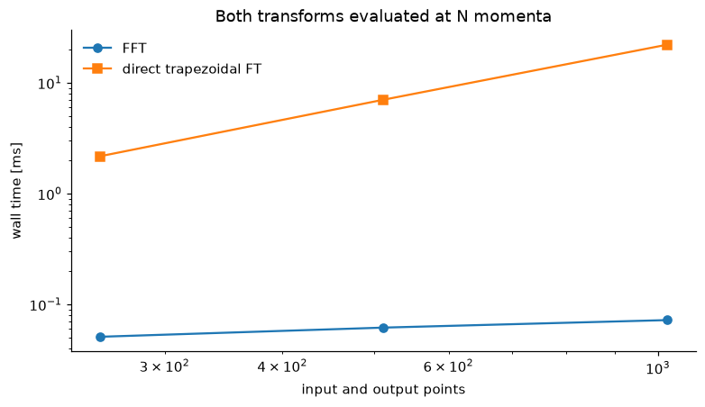

```python
timing_rows=[]
for n in [256,512,1024]:
    x=-8+16*np.arange(n)/n
    values=np.exp(-(x-center_test)**2/(2*sigma_test**2))
    fast_fourier_transform_1D(values,x)
    fft_times=[]
    for _ in range(7):
        start=time.perf_counter()
        transformed,k=fast_fourier_transform_1D(values,x)
        fft_times.append(time.perf_counter()-start)
    start=time.perf_counter()
    reference=fourier_transform(values,x,k)
    direct_time=time.perf_counter()-start
    fft_time=float(np.median(fft_times))
    timing_rows.append((n,fft_time,direct_time,direct_time/fft_time))
    check(f"FFT/direct agreement at N={n}",np.max(np.abs(transformed-reference))<1e-10,
          "Same momentum bins and negligible boundary values")
table(["N","FFT [ms]","direct [ms]","measured speed ratio"],[
    (n,f"{tf*1e3:.3f}",f"{td*1e3:.3f}",f"{ratio:.1f}x") for n,tf,td,ratio in timing_rows
], "Local timing: illustrative and hardware dependent")
fig,ax=plt.subplots(figsize=(7,4),layout="constrained")
ax.loglog([v[0] for v in timing_rows],[v[1]*1e3 for v in timing_rows],"o-",label="FFT")
ax.loglog([v[0] for v in timing_rows],[v[2]*1e3 for v in timing_rows],"s-",label="direct trapezoidal FT")
ax.set(xlabel="input and output points",ylabel="wall time [ms]",title="Both transforms evaluated at N momenta")
ax.legend()
finish(fig,"fourier_timing")
```

## 9. Project the full target before applying the fast transform

For momentum transfer $(\Delta_x,0)$, the implemented wrapper calculates $$ G_e(r,b_x)=\int db_y\,D_e(r,b_x,b_y),\qquad F_e(r,\Delta_x)=\frac1{h^2}\int db_x\,G_e(r,b_x)e^{-ib_x\Delta_x/h}. $$ It retains the two-dimensional event through its projection. The nonlinear profile $D_e$, rather than the thickness alone, is projected. No circular symmetry of the event is assumed.

For a shifted anisotropic Gaussian test profile $D=c\,e^{-(b_x-a_x)^2/(2s_x^2)-(b_y-a_y)^2/(2s_y^2)}$, the exact result is $$ F(\Delta_x)=\frac{2\pi c s_xs_y}{h^2} e^{-s_x^2\Delta_x^2/(2h^2)}e^{-ia_x\Delta_x/h}. $$ This checks the area normalization, fm-to-GeV conversion, and physical origin phase.

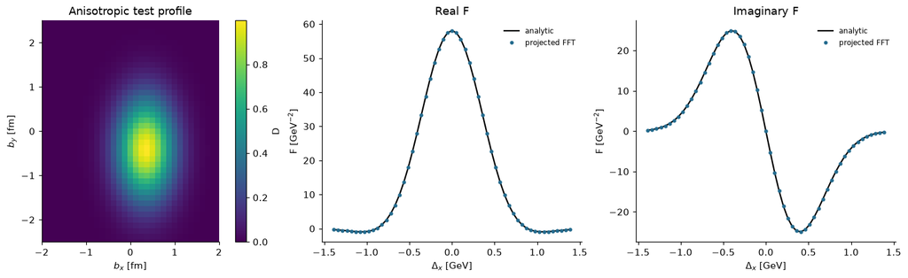

```python
gtest=transverse_grid(n=193,period=24.125)
gx,gy=gtest["points"].T
c=np.array([1.0,0.4,0.0])
sx=np.array([0.45,0.7,0.6])
sy=np.array([0.8,0.5,0.7])
ax0=np.array([0.35,-0.6,0.0])
ay0=np.array([-0.4,0.7,0.0])
gaussian_D=c[:,None]*np.exp(-((gx[None,:]-ax0[:,None])/sx[:,None])**2/2-
                           ((gy[None,:]-ay0[:,None])/sy[:,None])**2/2)
gaussian_F,gaussian_delta=dipole_profile_fourier_x(gaussian_D,gtest["bx"],gtest["by"])
exact_F=(2*np.pi*c*sx*sy/h**2)[:,None]*np.exp(
    -(sx[:,None]*gaussian_delta[None,:]/h)**2/2-
    1j*ax0[:,None]*gaussian_delta[None,:]/h)
gaussian_F_error=np.max(np.abs(gaussian_F-exact_F))
check("Projected FFT: Gaussian units and normalization",gaussian_F_error<1e-10,
      f"max absolute error {gaussian_F_error:.3e} GeV^-2")
check("Projected FFT: zero profile row",np.all(gaussian_F[2]==0),"Radius rows are not shifted or mixed")
shift=0.43
shifted_F,shifted_delta=dipole_profile_fourier_x(gaussian_D,gtest["bx"]+shift,gtest["by"])
shift_error=np.max(np.abs(shifted_F-gaussian_F*np.exp(-1j*gaussian_delta*shift/h)[None,:]))
check("Projected FFT: translation phase",shift_error<1e-10,f"max error {shift_error:.3e}")
fig,axes=plt.subplots(1,3,figsize=(14,4),layout="constrained")
mesh=axes[0].pcolormesh(gtest["bx"],gtest["by"],gaussian_D[0].reshape(gtest["shape"]).T,
                        cmap="viridis",shading="auto",rasterized=True)
axes[0].set(xlim=(-2,2),ylim=(-2.5,2.5),aspect="equal",
            xlabel=r"$b_x$ [fm]",ylabel=r"$b_y$ [fm]",title="Anisotropic test profile")
fig.colorbar(mesh,ax=axes[0],label="D")
sel=np.abs(gaussian_delta)<=1.4
for ax,part,title in [(axes[1],np.real,"Real F"),(axes[2],np.imag,"Imaginary F")]:
    ax.plot(gaussian_delta[sel],part(exact_F[0,sel]),color="black",label="analytic")
    ax.plot(gaussian_delta[sel],part(gaussian_F[0,sel]),"o",ms=3,color="#246B8E",label="projected FFT")
    ax.set(xlabel=r"$\Delta_x$ [GeV]",ylabel=r"F [GeV$^{-2}$]",title=title)
    ax.legend(fontsize=8)
finish(fig,"projected_fourier_audit")
```

## 10. Assemble the complete event amplitude

The helper now implemented in `amplitudes.py` computes $$ \mathcal A_{T,e}(\boldsymbol\Delta)= \frac{i}{2h^2}\int r\,dr\,H_T(r,|\boldsymbol\Delta|;Q)F_e(r,\boldsymbol\Delta). $$ The factor $1/2$ comes from $2\pi/(4\pi)$. The impact-area conversion is already inside $F_e$; the remaining $h^{-2}$ converts the radial area measure.

For the full one-axis FFT, $K=N_x$. Evaluate $H_T$ using the absolute values of the **returned** signed momentum grid, preserving column order:

| Stage | Shape |
| --- | --- |
| `F` and `H_T` | `(R, N_x)` |
| `r_fm[:, None]` | `(R, 1)` |
| `r_fm[:, None] * H_T * F` | `(R, N_x)` |
| Integrate over radius, axis 0 | `(N_x,)` |

The following notebook helper only wires together the existing production functions. It caches $H_T$, and never samples geometry inside a radius or momentum loop.

```python
OVERLAP_CACHE={}
def overlap_for_grid(radii,delta,Q=Q_GEV,nz=N_Z):
    key=(np.asarray(radii).tobytes(),np.asarray(delta).tobytes(),float(Q),int(nz))
    if key not in OVERLAP_CACHE:
        OVERLAP_CACHE[key]=gaus_lc_overlap_integral_z(wf,radii,np.abs(delta),Q_GeV=Q,nz=nz)
    return OVERLAP_CACHE[key]

def run_case(sources,radii=r_fm,grid=GRID,bj_x=BJ_X,Q=Q_GEV,nz=N_Z,keep_profile=False):
    D=profile_on_grid(sources,radii,grid,bj_x)
    F,delta=dipole_profile_fourier_x(D,grid["bx"],grid["by"])
    H=overlap_for_grid(radii,delta,Q,nz)
    A=photon_target_amplitude_T(radii,H,F)
    result={"F":F,"delta":delta,"H":H,"A":A,"r":np.asarray(radii)}
    if keep_profile:
        result["D"]=D
    return result

RESULTS={}
amplitude_rows=[]
for key,sources in CASES.items():
    result=run_case(sources,keep_profile=True)
    delta,A=result["delta"],result["A"]
    zero=int(np.argmin(np.abs(delta)))
    check(f"Amplitude shape and finiteness: {key}",
          A.shape==(N_B,) and np.iscomplexobj(A) and np.all(np.isfinite(A)),
          f"F {result['F'].shape}; H {result['H'].shape}; A {A.shape}")
    check(f"Forward amplitude phase: {key}",abs(A[zero].real)<1e-11 and A[zero].imag>0,
          f"A(0) = {A[zero]}")
    # The even-length FFT has an unpaired Nyquist bin; compare actual +/- partners.
    chosen=np.array([zero-6,zero-2,zero,zero+2,zero+6])
    pair_error=np.max(np.abs(A[chosen]+A[2*zero-chosen].conjugate()))
    check(f"Amplitude conjugation symmetry: {key}",pair_error<1e-10,
          f"A(-Delta) = -A(Delta)*; max error {pair_error:.3e}")
    direct=[]
    for k in chosen:
        source=np.einsum("r,r,r,rp->p",trap_weights(r_fm),r_fm,result["H"][:,k],result["D"])
        phase=np.exp(-1j*GRID["points"][:,0]*delta[k]/h)
        direct.append(1j*np.dot(area_weights(GRID)*phase,source)/(2*h**4))
    direct_error=np.max(np.abs(A[chosen]-np.asarray(direct)))
    check(f"Full direct amplitude comparison: {key}",direct_error<1e-9,
          f"reverse integration order and explicit b phase; error {direct_error:.3e} GeV^-2")
    amplitude_rows.append((*key,f"{A[zero].imag:.8f}",f"{direct_error:.3e}"))
    del result["D"]               # Keep compact outputs, not all radius-by-position arrays.
    RESULTS[key]=result
table(["Geometry","Mode","Im A(0) [GeV^-2]","direct comparison error"],amplitude_rows,
      "One independently sampled event per geometry, with paired target models")
```

**One independently sampled event per geometry, with paired target models**

| Geometry | Mode | Im A(0) [GeV^-2] | direct comparison error |
| --- | --- | --- | --- |
| WS / 3pF | nucleon | 39.56981965 | 1.792e-14 |
| WS / 3pF | hotspot | 36.49948891 | 1.641e-14 |
| alpha | nucleon | 41.18267911 | 4.263e-14 |
| alpha | hotspot | 37.31518640 | 1.177e-14 |

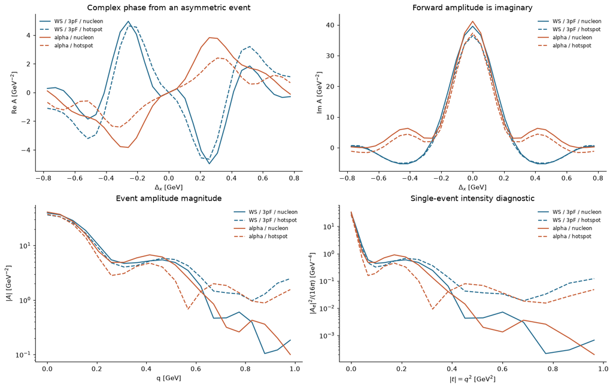

```python
fig,axes=plt.subplots(2,2,figsize=(13,8.2),layout="constrained")
for key,result in RESULTS.items():
    delta,A=result["delta"],result["A"]
    signed=np.abs(delta)<=0.8
    pos=positive_bins(delta,1.0)
    style=curve_style(key)
    axes[0,0].plot(delta[signed],A[signed].real,**style)
    axes[0,1].plot(delta[signed],A[signed].imag,**style)
    axes[1,0].semilogy(delta[pos],np.maximum(np.abs(A[pos]),1e-12),**style)
    axes[1,1].semilogy(delta[pos]**2,np.maximum(np.abs(A[pos])**2/(16*np.pi),1e-24),**style)
axes[0,0].set(xlabel=r"$\Delta_x$ [GeV]",ylabel=r"Re A [GeV$^{-2}$]",title="Complex phase from an asymmetric event")
axes[0,1].set(xlabel=r"$\Delta_x$ [GeV]",ylabel=r"Im A [GeV$^{-2}$]",title="Forward amplitude is imaginary")
axes[1,0].set(xlabel="q [GeV]",ylabel=r"$|A|$ [GeV$^{-2}$]",title="Event amplitude magnitude")
axes[1,1].set(xlabel=r"$|t|=q^2$ [GeV$^2$]",ylabel=r"$|A_e|^2/(16\pi)$ [GeV$^{-4}$]",
              title="Single-event intensity diagnostic")
for ax in axes.ravel():
    ax.legend(fontsize=8)
finish(fig,"complete_event_amplitudes")
```

The last panel is deliberately labeled **single-event intensity**. It is not yet the coherent or incoherent ensemble cross section. Its detailed minima depend on the particular event and its orientation.

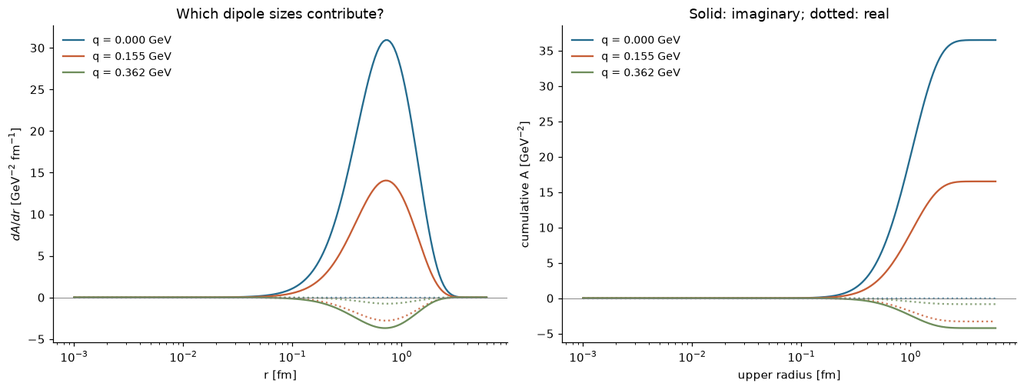

```python
# An independent closed-form radial integral checks the new amplitude prefactor.
r_norm=np.array([0.03,0.11,0.42,1.25,2.0])
H_const=np.broadcast_to(np.array([1.,-2.,0.,0.5]),(len(r_norm),4))
F_const=np.broadcast_to(np.array([2.,1.+3j,-1j,-2.+0.7j]),H_const.shape)
A_norm=photon_target_amplitude_T(r_norm,H_const,F_const)
A_exact=(1j*(r_norm[-1]**2-r_norm[0]**2)/(4*h**2))*H_const[0]*F_const[0]
check("Radial normalization on a nonuniform grid",
      np.allclose(A_norm,A_exact,rtol=1e-14,atol=1e-13),
      "Analytic integral of r; includes signed H and complex F")
check("Zero response gives zero amplitude",
      np.all(photon_target_amplitude_T(r_norm,H_const,np.zeros_like(F_const))==0),
      "No spurious offset or lost K axis")

base_key=("WS / 3pF","hotspot")
base=RESULTS[base_key]
zero=int(np.argmin(np.abs(base["delta"])))
chosen=[zero,zero+3,zero+7]
fig,axes=plt.subplots(1,2,figsize=(12,4.5),layout="constrained")
for k,color in zip(chosen,["#246B8E","#C65D35","#6e8d5b"]):
    # Differential contribution to A per unit physical r.
    contribution=1j*r_fm*base["H"][:,k]*base["F"][:,k]/(2*h**2)
    cumulative=cumulative_trapezoid(contribution,x=r_fm,initial=0)
    label=f"q = {base['delta'][k]:.3f} GeV"
    axes[0].semilogx(r_fm,contribution.imag,color=color,label=label)
    axes[0].semilogx(r_fm,contribution.real,color=color,ls=":",alpha=0.8)
    axes[1].semilogx(r_fm,cumulative.imag,color=color,label=label)
    axes[1].semilogx(r_fm,cumulative.real,color=color,ls=":",alpha=0.8)
    check(f"Cumulative radial integral at bin {k}",
          abs(cumulative[-1]-base["A"][k])<1e-10,"Matches the production amplitude endpoint")
axes[0].set(xlabel="r [fm]",ylabel=r"$dA/dr$ [GeV$^{-2}$ fm$^{-1}$]",
            title="Which dipole sizes contribute?")
axes[1].set(xlabel="upper radius [fm]",ylabel=r"cumulative A [GeV$^{-2}$]",
            title="Solid: imaginary; dotted: real")
for ax in axes:
    ax.axhline(0,color="gray",lw=0.6)
    ax.legend(fontsize=9)
finish(fig,"radial_contributions")
```

## 11. Phase and orientation checks on a real event

Translating the target and its integration window by $a_x$ multiplies the amplitude by $e^{-i\Delta_xa_x/h}$. It preserves its magnitude. We test that law with the full FFT-to-amplitude chain.

Rotating an asymmetric target while keeping the momentum direction fixed can instead change the magnitude. This is a useful demonstration that the one-axis projection has preserved directional information. The same sampled hotspots rotate with their parents.

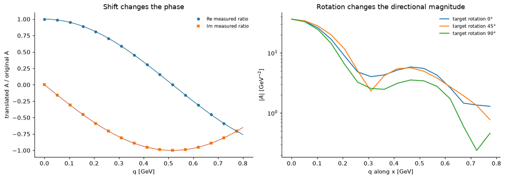

```python
shift=0.6
base_sources=CASES[base_key]
base_D=profile_on_grid(base_sources,r_fm,GRID,BJ_X)
shifted_F,shifted_delta=dipole_profile_fourier_x(base_D,GRID["bx"]+shift,GRID["by"])
shifted_A=photon_target_amplitude_T(r_fm,base["H"],shifted_F)
expected_shift=base["A"]*np.exp(-1j*base["delta"]*shift/h)
shift_amp_error=np.max(np.abs(shifted_A-expected_shift))
check("Complete amplitude translation phase",shift_amp_error<1e-9,
      f"max error {shift_amp_error:.3e} GeV^-2; source/window translate together")
del base_D

rotation_results={0:base}
for degrees in [45,90]:
    angle=np.deg2rad(degrees)
    rotation=np.array([[np.cos(angle),-np.sin(angle)],[np.sin(angle),np.cos(angle)]])
    rotated=base_sources["centers"].copy()
    rotated[:,:2]=rotated[:,:2]@rotation.T
    sources={**base_sources,"centers":rotated}
    rotation_results[degrees]=run_case(sources)
fig,axes=plt.subplots(1,2,figsize=(12,4.2),layout="constrained")
pos=positive_bins(base["delta"],0.8)
phase_valid=pos & (np.abs(base["A"])>1e-5*np.abs(base["A"][zero]))
ratio=shifted_A[phase_valid]/base["A"][phase_valid]
axes[0].plot(base["delta"][phase_valid],ratio.real,"o",ms=4,label="Re measured ratio")
axes[0].plot(base["delta"][phase_valid],ratio.imag,"s",ms=4,label="Im measured ratio")
q_line=np.linspace(0,0.8,300)
axes[0].plot(q_line,np.cos(q_line*shift/h),color="#246B8E",lw=1)
axes[0].plot(q_line,-np.sin(q_line*shift/h),color="#C65D35",lw=1)
axes[0].set(xlabel="q [GeV]",ylabel="translated A / original A",title="Shift changes the phase")
axes[0].legend(fontsize=8)
for degrees,result in rotation_results.items():
    axes[1].semilogy(result["delta"][pos],np.maximum(np.abs(result["A"][pos]),1e-12),
                     label=f"target rotation {degrees}°")
axes[1].set(xlabel="q along x [GeV]",ylabel=r"$|A|$ [GeV$^{-2}$]",title="Rotation changes the directional magnitude")
axes[1].legend(fontsize=8)
finish(fig,"event_translation_and_rotation")
```

## 12. Energy and virtuality in the completed amplitude

First hold the sources fixed and vary $W$ through $x$. This isolates the GBW energy dependence. A hotspot configuration held fixed while changing $x$ is a **conditional diagnostic**, not a draw from the hotspot law at each new energy.

The second energy panel therefore samples fresh hotspots at every $x(W)$, around the same nucleons. Three draws per energy illustrate the extra configuration dependence; the error bars show their sample spread, not the uncertainty of a physical prediction. At a given energy, every draw is frozen throughout all integrals.

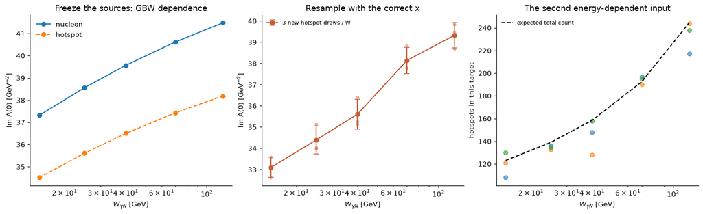

```python
W_examples=np.array([15.,25.,40.,70.,120.])
frozen_energy={mode:[] for mode in MODES}
resampled_A0,resampled_counts=[],[]
energy_rng=rng_for(100)
for W in W_examples:
    x_value=float(x_from_W(W,Q_GEV))
    for mode in MODES:
        value=run_case(CASES["WS / 3pF",mode],bj_x=x_value)
        frozen_energy[mode].append(value["A"][np.argmin(np.abs(value["delta"]))].imag)
    draws,counts_at_W=[],[]
    for draw in range(3):
        hs,parents,weights,counts=sample_target_hotspots(EVENTS["WS / 3pF"][0],x_value,RHO_HS,energy_rng)
        sources={"centers":hs,"weights":weights,"sigma":SIGMA_HS_FM,"A":16}
        value=run_case(sources,bj_x=x_value)
        draws.append(value["A"][np.argmin(np.abs(value["delta"]))].imag)
        counts_at_W.append(len(hs))
    resampled_A0.append(draws)
    resampled_counts.append(counts_at_W)
resampled_A0=np.asarray(resampled_A0)
resampled_counts=np.asarray(resampled_counts)
for mode in MODES:
    check(f"Frozen-source A(0) increases with W: {mode}",
          np.all(np.diff(frozen_energy[mode])>0),
          "Fixed Q and positive forward overlap; GBW is the only varying component")
fig,axes=plt.subplots(1,3,figsize=(14,4.2),layout="constrained")
for mode in MODES:
    axes[0].semilogx(W_examples,frozen_energy[mode],"o"+MODE_STYLES[mode],label=mode)
axes[0].set(xlabel=r"$W_{\gamma N}$ [GeV]",ylabel=r"Im A(0) [GeV$^{-2}$]",
            title="Freeze the sources: GBW dependence")
axes[0].legend()
axes[1].errorbar(W_examples,resampled_A0.mean(axis=1),yerr=resampled_A0.std(axis=1,ddof=1),
                 fmt="o-",capsize=4,color="#C65D35",label="3 new hotspot draws / W")
for j in range(3):
    axes[1].scatter(W_examples,resampled_A0[:,j],s=15,color="#C65D35",alpha=0.4)
axes[1].set(xscale="log",xlabel=r"$W_{\gamma N}$ [GeV]",ylabel=r"Im A(0) [GeV$^{-2}$]",
            title="Resample with the correct x")
axes[1].legend(fontsize=8)
for j in range(3):
    axes[2].plot(W_examples,resampled_counts[:,j],"o",alpha=0.6)
rate=mean_hotspot_count(x_from_W(W_examples),RHO_HS)
axes[2].plot(W_examples,16*rate/(-np.expm1(-rate)),color="black",ls="--",label="expected total count")
axes[2].set(xscale="log",xlabel=r"$W_{\gamma N}$ [GeV]",ylabel="hotspots in this target",
            title="The second energy-dependent input")
axes[2].legend(fontsize=8)
finish(fig,"energy_in_complete_amplitude")
```

### Changing $Q$: isolate the overlap or keep the energy fixed

For smooth nucleons the source distribution is independent of $x$. We can therefore compare two clean controls: hold $x$ fixed to isolate the overlap, or hold $W$ fixed so $x(W,Q)$ changes along with the overlap. The longitudinal amplitude is a separate future component for electroproduction.

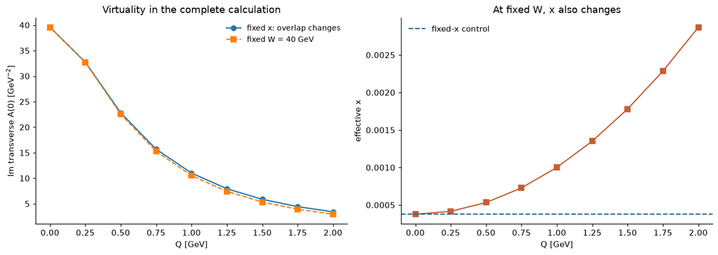

```python
Q_values=np.linspace(0,2,9)
fixed_x_Q,fixed_W_Q=[],[]
smooth=RESULTS["WS / 3pF","nucleon"]
smooth_zero=np.argmin(np.abs(smooth["delta"]))
for Q in Q_values:
    H=overlap_for_grid(r_fm,smooth["delta"],Q=Q)
    fixed_x_Q.append(photon_target_amplitude_T(r_fm,H,smooth["F"])[smooth_zero].imag)
    result=run_case(CASES["WS / 3pF","nucleon"],
                    bj_x=float(x_from_W(W_GAMMAN_GEV,Q)),Q=Q)
    fixed_W_Q.append(result["A"][smooth_zero].imag)
fig,axes=plt.subplots(1,2,figsize=(12,4.2),layout="constrained")
axes[0].plot(Q_values,fixed_x_Q,"o-",label="fixed x: overlap changes")
axes[0].plot(Q_values,fixed_W_Q,"s--",label=f"fixed W = {W_GAMMAN_GEV:g} GeV")
axes[0].set(xlabel="Q [GeV]",ylabel=r"Im transverse A(0) [GeV$^{-2}$]",title="Virtuality in the complete calculation")
axes[0].legend(fontsize=9)
axes[1].plot(Q_values,[x_from_W(W_GAMMAN_GEV,Q) for Q in Q_values],"s-",color="#C65D35")
axes[1].axhline(BJ_X,color="#246B8E",ls="--",label="fixed-x control")
axes[1].set(xlabel="Q [GeV]",ylabel="effective x",title="At fixed W, x also changes")
axes[1].legend()
finish(fig,"virtuality_in_complete_amplitude")
```

## 13. Different events give different amplitudes

The four curves in each panel use independent nuclear events. The nucleon and hotspot columns share the underlying nucleons for each event index. Only the plot is normalized by each event's own $|A(0)|$; the saved amplitudes retain their absolute normalization and complex phases.

These examples show the fluctuations that the future ensemble calculation will measure. Four events are not enough to estimate an incoherent spectrum reliably.

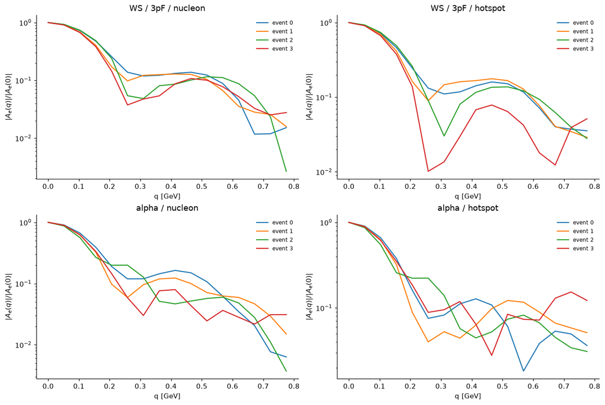

```python
GALLERY={}
fig,axes=plt.subplots(2,2,figsize=(12,8),layout="constrained")
for row,model in enumerate(MODEL_NAMES):
    for col,mode in enumerate(MODES):
        amplitudes=[]
        for event_index in range(N_EXAMPLE_EVENTS):
            if event_index==0:
                result=RESULTS[model,mode]
            else:
                nucleons=EVENTS[model][event_index]
                if mode=="nucleon":
                    sources={"centers":nucleons,"weights":np.ones(16),"sigma":SIGMA_N_FM,"A":16}
                else:
                    hs,parents,weights,counts=sample_target_hotspots(
                        nucleons,BJ_X,RHO_HS,rng_for(200+100*row+event_index))
                    sources={"centers":hs,"weights":weights,"sigma":SIGMA_HS_FM,"A":16}
                result=run_case(sources)
            A,delta=result["A"],result["delta"]
            pos=positive_bins(delta,0.8)
            normalization=abs(A[np.argmin(np.abs(delta))])
            axes[row,col].semilogy(delta[pos],np.maximum(np.abs(A[pos])/normalization,1e-12),
                                  label=f"event {event_index}")
            amplitudes.append(A)
        GALLERY[model,mode]=np.asarray(amplitudes)
        axes[row,col].set(xlabel="q [GeV]",ylabel=r"$|A_e(q)|/|A_e(0)|$",
                          title=f"{model} / {mode}")
        axes[row,col].legend(fontsize=8)
finish(fig,"event_fluctuation_gallery")
```

## 14. Numerical convergence: separate the controls

An implementation identity can pass while a chosen numerical grid is too coarse. Here we freeze one WS/hotspot event and vary one numerical control at a time.

- Radius resolution and radius cutoffs use one dense set of $H,F$ samples.
- Transverse spacing changes at **fixed FFT period**, so momentum bins agree.
- Box size changes the momentum spacing; that comparison therefore uses $q=0$.
- The $z$-node study was shown in section 7.

For multi-momentum comparisons, errors are normalized to the reference $|A(0)|$. Relative errors near a diffractive minimum can diverge even when the absolute error is small. These tests establish accuracy for this demonstration, not a universal choice of grids for every future parameter set. Reference points compared with themselves are omitted from the error curves. Differences below $10^{-16}$ are displayed at that plotting floor.

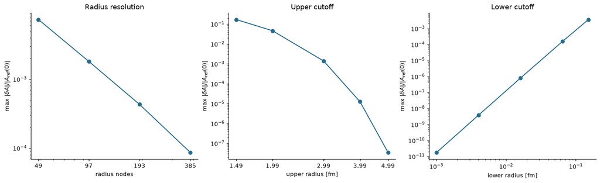

```python
dense_r=np.geomspace(0.00025,6.0,769)
dense=run_case(base_sources,radii=dense_r)
delta=dense["delta"]
selected=np.flatnonzero(positive_bins(delta,0.6))
zero_dense=int(np.argmin(np.abs(delta)))
scale=abs(dense["A"][zero_dense])
radial_rows=[]
for stride in [16,8,4,2,1]:
    indices=np.arange(0,len(dense_r),stride)
    value=photon_target_amplitude_T(dense_r[indices],dense["H"][indices],dense["F"][indices])
    error=np.max(np.abs(value[selected]-dense["A"][selected]))/scale
    radial_rows.append((len(indices),float(error)))
upper_rows=[]
for cutoff in [1.5,2.0,3.0,4.0,5.0,6.0]:
    indices=np.flatnonzero(dense_r<=cutoff)
    value=photon_target_amplitude_T(dense_r[indices],dense["H"][indices],dense["F"][indices])
    error=np.max(np.abs(value[selected]-dense["A"][selected]))/scale
    upper_rows.append((dense_r[indices[-1]],float(error)))
lower_rows=[]
for cutoff in [0.00025,0.001,0.004,0.016,0.064,0.15]:
    indices=np.flatnonzero(dense_r>=cutoff)
    value=photon_target_amplitude_T(dense_r[indices],dense["H"][indices],dense["F"][indices])
    error=np.max(np.abs(value[selected]-dense["A"][selected]))/scale
    lower_rows.append((dense_r[indices[0]],float(error)))
baseline_radial_error=np.max(np.abs(base["A"][selected]-dense["A"][selected]))/scale
check("Default radial grid versus refined grid",baseline_radial_error<3e-3,
      f"max |delta A|/|A_ref(0)| at q <= 0.6 GeV: {baseline_radial_error:.3e}; tolerance 0.003")
fig,axes=plt.subplots(1,3,figsize=(14,4.2),layout="constrained")
for ax,rows,xlabel,title in [
    (axes[0],radial_rows,"radius nodes","Radius resolution"),
    (axes[1],upper_rows,"upper radius [fm]","Upper cutoff"),
    (axes[2],lower_rows,"lower radius [fm]","Lower cutoff"),
]:
    values=np.asarray([row for row in rows if row[1]>0])
    ax.loglog(values[:,0],np.maximum(values[:,1],1e-16),"o-",color="#246B8E")
    ax.set(xlabel=xlabel,ylabel=r"max $|\delta A|/|A_{\rm ref}(0)|$",title=title)
    if ax is not axes[2]:
        ax.set_xticks(values[:,0],labels=[f"{value:.3g}" for value in values[:,0]])
        ax.xaxis.set_minor_formatter(NullFormatter())
finish(fig,"radial_convergence")
```

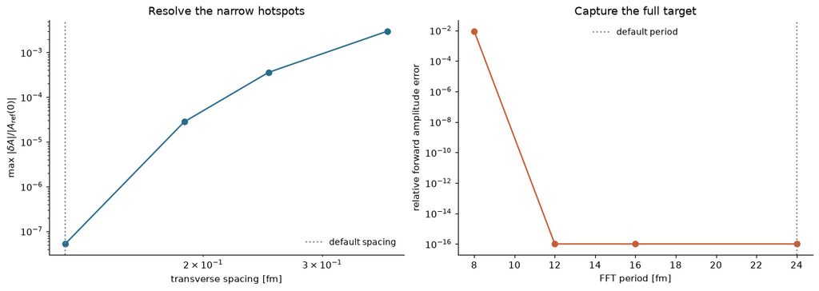

**Convergence evidence for the frozen WS/hotspot demonstration event**

| Default-grid comparison | Measured error | Criterion |
| --- | --- | --- |
| Radial grid | 3.134e-04 | < 0.003, normalized to A_ref(0) |
| Transverse spacing | 5.198e-08 | < 0.003, normalized to A_ref(0) |
| Transverse box | 0.000e+00 | < 1e-5 at q = 0 |

```python
spacing_results=[]
spacing_reference=run_case(base_sources,grid=transverse_grid(n=256,period=B_PERIOD_FM))
ref_delta=spacing_reference["delta"]
ref_indices=np.flatnonzero(positive_bins(ref_delta,0.6))
reference_A=spacing_reference["A"][ref_indices]
spacing_scale=abs(reference_A[0])
for n in [64,96,128,192,256]:
    grid=transverse_grid(n=n,period=B_PERIOD_FM)
    result=spacing_reference if n==256 else run_case(base_sources,grid=grid)
    indices=np.array([np.argmin(abs(result["delta"]-q)) for q in ref_delta[ref_indices]])
    check(f"Same momentum bins at transverse N={n}",
          np.allclose(result["delta"][indices],ref_delta[ref_indices],atol=1e-13,rtol=1e-12),
          "Fixed FFT period permits a direct comparison")
    error=np.max(np.abs(result["A"][indices]-reference_A))/spacing_scale
    spacing_results.append((grid["spacing"],float(error)))
default_spacing_error=next(error for spacing,error in spacing_results
                           if np.isclose(spacing,GRID["spacing"]))
check("Default transverse spacing versus refined grid",default_spacing_error<3e-3,
      f"max |delta A|/|A_ref(0)|: {default_spacing_error:.3e}; tolerance 0.003")

window_results=[]
window_reference=run_case(base_sources,grid=transverse_grid(n=256,period=32.0))
window_A0=window_reference["A"][np.argmin(abs(window_reference["delta"]))]
for n in [64,96,128,192,256]:
    grid=transverse_grid(n=n,period=n*0.125)
    result=window_reference if n==256 else run_case(base_sources,grid=grid)
    value=result["A"][np.argmin(abs(result["delta"]))]
    window_results.append((grid["period"],float(abs(value/window_A0-1))))
default_window_error=next(error for width,error in window_results if np.isclose(width,B_PERIOD_FM))
check("Default transverse box versus 32-fm box",default_window_error<1e-5,
      f"forward amplitude relative difference {default_window_error:.3e}; same 0.125-fm spacing")
fig,axes=plt.subplots(1,2,figsize=(12,4.2),layout="constrained")
values=np.asarray([row for row in spacing_results if row[1]>0])
axes[0].loglog(values[:,0],np.maximum(values[:,1],1e-16),"o-",color="#246B8E")
axes[0].axvline(GRID["spacing"],color="gray",ls=":",label="default spacing")
axes[0].set(xlabel="transverse spacing [fm]",ylabel=r"max $|\delta A|/|A_{\rm ref}(0)|$",
            title="Resolve the narrow hotspots")
axes[0].legend(fontsize=9)
values=np.asarray(window_results[:-1])   # Omit the 32-fm reference compared with itself.
axes[1].semilogy(values[:,0],np.maximum(values[:,1],1e-16),"o-",color="#C65D35")
axes[1].axvline(B_PERIOD_FM,color="gray",ls=":",label="default period")
axes[1].set(xlabel="FFT period [fm]",ylabel="relative forward amplitude error",
            title="Capture the full target")
axes[1].legend(fontsize=9)
finish(fig,"transverse_convergence")
table(["Default-grid comparison","Measured error","Criterion"],[
    ("Radial grid",f"{baseline_radial_error:.3e}","< 0.003, normalized to A_ref(0)"),
    ("Transverse spacing",f"{default_spacing_error:.3e}","< 0.003, normalized to A_ref(0)"),
    ("Transverse box",f"{default_window_error:.3e}","< 1e-5 at q = 0"),
], "Convergence evidence for the frozen WS/hotspot demonstration event")
```

## 15. Deliberate failures and the final audit

The public functions should reject incompatible units represented as complex coordinates, invalid domains, mismatched radius/momentum arrays, and a finite-A opacity outside the intended absorptive branch. The checks below verify representative failure paths; they do not clip, silently reshape, or replace an invalid physical configuration.

```python
def expects_value_error(name,call):
    try:
        call()
    except ValueError:
        check(name,True,"Raised ValueError as intended")
    else:
        check(name,False,"Invalid input was accepted")

expects_value_error("Reject x=0",lambda:gbw_dipole_amplitude(0,0.2))
expects_value_error("Reject r=0 in raw overlap",lambda:gaus_lc_overlap_T(wf,[0.5],[0.0]))
expects_value_error("Reject negative momentum magnitude",lambda:gaus_lc_overlap_integral_z(
    wf,[0.2],[-0.1],Q_GeV=0,nz=64))
expects_value_error("Reject nonuniform FFT input",lambda:fast_fourier_transform_1D(
    np.ones(4),np.array([0.,0.1,0.3,0.7])))
expects_value_error("Reject mismatched H/F grids",lambda:photon_target_amplitude_T(
    [0.1,0.2],np.ones((2,3)),np.ones((2,4))))
expects_value_error("Reject nonincreasing radii",lambda:photon_target_amplitude_T(
    [0.2,0.1],np.ones((2,3)),np.ones((2,3))))
expects_value_error("Reject finite-A opacity above one",lambda:nuclear_dipole_profile(
    BJ_X,[1.0],np.array([[0.,0.]]),np.zeros((1,3)),GBW_PAPER,
    weights=np.ones(1),sigma_fm=0.001,sigma_0_fm2=SIGMA0_FM2,A=1))

table(["Check","Result","Evidence"],[
    (item["name"],"PASS" if item["passed"] else "FAIL",item["detail"]) for item in CHECKS
],f"{sum(item['passed'] for item in CHECKS)} / {len(CHECKS)} deterministic and numerical checks passed")
```

**82 / 82 deterministic and numerical checks passed**

| Check | Result | Evidence |
| --- | --- | --- |
| W-to-x photoproduction limit | PASS | Uses meson mass and W squared |
| Increasing W decreases x | PASS | Fixed Q and meson mass |
| Q_s^2(x0) = Q0^2 | PASS | Q0 is squared once |
| GBW zero-size limit | PASS | N(x,0) = 0 exactly |
| GBW characteristic radius | PASS | r = 2 h / Qs |
| GBW small-r expansion | PASS | Independent leading-order expansion |
| GBW saturation | PASS | Large dipole limit |
| Source normalization: ('WS / 3pF', 'nucleon') | PASS | Weights retain the original A |
| Grid captures target weight: ('WS / 3pF', 'nucleon') | PASS | integrated T = 16; exact full-plane value 16 |
| Source normalization: ('WS / 3pF', 'hotspot') | PASS | Weights retain the original A |
| Grid captures target weight: ('WS / 3pF', 'hotspot') | PASS | integrated T = 16; exact full-plane value 16 |
| Source normalization: ('alpha', 'nucleon') | PASS | Weights retain the original A |
| Grid captures target weight: ('alpha', 'nucleon') | PASS | integrated T = 16; exact full-plane value 16 |
| Source normalization: ('alpha', 'hotspot') | PASS | Weights retain the original A |
| Grid captures target weight: ('alpha', 'hotspot') | PASS | integrated T = 16; exact full-plane value 16 |
| Finite-A range: ('WS / 3pF', 'nucleon') | PASS | 0 <= D <= 2 |
| Finite-A range: ('WS / 3pF', 'hotspot') | PASS | 0 <= D <= 2 |
| Finite-A range: ('alpha', 'nucleon') | PASS | 0 <= D <= 2 |
| Finite-A range: ('alpha', 'hotspot') | PASS | 0 <= D <= 2 |
| Nuclear zero-r limit: ('WS / 3pF', 'nucleon') | PASS | D(x,0,b) = 0 |
| Thin-target expansion: ('WS / 3pF', 'nucleon') | PASS | peak-normalized error 7.128e-10 |
| Nuclear zero-r limit: ('WS / 3pF', 'hotspot') | PASS | D(x,0,b) = 0 |
| Thin-target expansion: ('WS / 3pF', 'hotspot') | PASS | peak-normalized error 9.929e-10 |
| Nuclear zero-r limit: ('alpha', 'nucleon') | PASS | D(x,0,b) = 0 |
| Thin-target expansion: ('alpha', 'nucleon') | PASS | peak-normalized error 5.249e-10 |
| Nuclear zero-r limit: ('alpha', 'hotspot') | PASS | D(x,0,b) = 0 |
| Thin-target expansion: ('alpha', 'hotspot') | PASS | peak-normalized error 1.292e-09 |
| Wavefunction derivative in GeV^-1 coordinate | PASS | peak-normalized finite-difference error 8.340e-11 |
| Overlap z-exchange symmetry | PASS | z <-> 1-z at nonzero Q |
| Dipole-angle integral gives J0 | PASS | max complex error from 2048 angles 3.377e-16 |

[output cut: 52 more lines]

### Saved artifacts and reproducibility

The numerical snapshot contains the radius and momentum grids, all four complex event amplitudes and profile transforms, their shared overlap, the example target centers/weights, and the individual-event gallery. The manifest records the exact parameters, source-file hashes, seed, convergence results, and every check.

All images are also saved as separate PNGs in `amplitude_debug_outputs`. The notebook runs independently of notebook 1's saved state or kernel.

```python
snapshot={"r_fm":r_fm,"delta_x_GeV":base["delta"],"H_T":base["H"],
          "W_GeV":W_examples,"resampled_A0":resampled_A0,"resampled_hotspot_counts":resampled_counts}
for key,sources in CASES.items():
    prefix=("ws" if key[0]=="WS / 3pF" else "alpha")+"_"+key[1]
    snapshot[prefix+"_centers_fm"]=sources["centers"]
    snapshot[prefix+"_weights"]=sources["weights"]
    snapshot[prefix+"_F_GeV_m2"]=RESULTS[key]["F"]
    snapshot[prefix+"_A_GeV_m2"]=RESULTS[key]["A"]
    snapshot[prefix+"_gallery_A_GeV_m2"]=GALLERY[key]
    snapshot[prefix+"_T_fm_m2"]=T_MAPS[key].reshape(GRID["shape"])
    if key[1]=="hotspot":
        snapshot[prefix+"_parents"]=sources["parents"]
        snapshot[prefix+"_counts"]=sources["counts"]
np.savez_compressed(OUTPUT_DIR/"amplitude_samples.npz",**snapshot)
source_names=["parameters.py","densities.py","geometry.py","fourier_transform.py",
              "wavefunctions.py","amplitudes.py"]
manifest={
    "seed":SEED,"W_gammaN_GeV":W_GAMMAN_GEV,"Q_GeV":Q_GEV,"M_V_GeV":M_V_GEV,"x":BJ_X,
    "kinematics":"x=(Q^2+M_V^2)/(Q^2+W_gammaN^2), no t dependence",
    "parameters":{"gbw":asdict(GBW_PAPER),"hotspots":asdict(RHO_HS),
                  "wavefunction":asdict(wf),"alpha":asdict(O16_ALPHA),"3pf":asdict(O16_3PF)},
    "grid":{"N_r":N_R,"r_min_fm":R_MIN_FM,"r_max_fm":R_MAX_FM,"N_z":N_Z,
            "N_b":N_B,"period_fm":B_PERIOD_FM,"spacing_fm":GRID["spacing"]},
    "profile_widths_fm":{"nucleon":SIGMA_N_FM,"hotspot":SIGMA_HS_FM},
    "sigma_0_fm2":SIGMA0_FM2,"checks":CHECKS,
    "convergence":{"radial_error":float(baseline_radial_error),
                   "transverse_spacing_error":float(default_spacing_error),
                   "box_forward_error":float(default_window_error)},
    "versions":{"python":platform.python_version(),"numpy":np.__version__,
                "scipy":scipy.__version__,"matplotlib":matplotlib.__version__},
    "source_sha256":{name:hashlib.sha256((ROOT/"upcmodel"/name).read_bytes()).hexdigest()
                     for name in source_names},
    "figures":[path.name for path in FIGURE_PATHS],
    "elapsed_seconds":time.perf_counter()-START_TIME,
}
(OUTPUT_DIR/"amplitude_audit.json").write_text(json.dumps(manifest,indent=2)+"\n")
print(f"Saved {len(FIGURE_PATHS)} figures, amplitude_samples.npz, and amplitude_audit.json.")
print(f"Runtime: {manifest['elapsed_seconds']:.1f} seconds.")
```

```
Saved 20 figures, amplitude_samples.npz, and amplitude_audit.json.
Runtime: 20.3 seconds.
```

## 16. What is complete, and what to implement next

**Complete in this demonstration:** the transverse amplitude of one fixed target event for momentum transfer along a chosen axis, using the current geometry, GBW dipole strength, finite-A profile, Gaus-LC overlap, and projected FFT. The tests check the implementation and numerical convergence on the stated domain. They do not establish agreement with experimental data.

**Next module: ensemble averages and baseline spectra.** At fixed $x,Q$ and a common momentum grid, collect complex amplitudes with shape $(E,K)$. Then calculate $$ \overline{\mathcal A}_k=\frac1E\sum_e\mathcal A_{ek},\qquad I_k=\frac1E\sum_e|\mathcal A_{ek}|^2, $$ $$ \frac{d\sigma_{\rm coh}}{d|t|}=\frac{|\overline{\mathcal A}|^2}{16\pi},\qquad \frac{d\sigma_{\rm inc}}{d|t|}=\frac{\langle|\mathcal A-\overline{\mathcal A}|^2\rangle}{16\pi}. $$ The centered expression avoids subtracting nearly equal large numbers. With the $1/E$ convention it is exactly $I-|\overline{\mathcal A}|^2$; finite-sample bias and uncertainty should be assessed explicitly as the ensemble grows. Both arrays have shape $(K,)$, in GeV$^{-4}$. [Good–Walker expressions in the model reference](https://arxiv.org/html/2312.11320v2#S2)

An appropriate next interface is `ensemble_spectra(amplitudes)` in a new `upcmodel/observables.py`. It should return the complex mean amplitude, the mean intensity, and the two baseline spectra. Its first tests are: identical events give zero incoherent spectrum; a common phase leaves both spectra unchanged; centered variance matches the subtraction formula. This notebook does not add that physics module.

Randomly oriented targets allow an ensemble study along a fixed momentum axis. Observables retaining azimuthal correlations require the corresponding angular information. Skewness/real-part corrections, UPC photon fluxes, rapidity-to-energy kinematics, and two-pathway interference are later stages.

**Reference conventions used here**

- [Energy-dependent hotspot model](https://arxiv.org/html/2312.11320v2): midpoint phase, effective $x$, finite-A prescription, and current hotspot/GBW parameters.
- [Kowalski, Motyka and Watt](https://arxiv.org/pdf/hep-ph/0606272): transverse Gaus-LC overlap and Table 1 rho parameters. The hotspot reference uses a boosted-Gaussian wavefunction and a small nonzero photon virtuality in its fits; this notebook tests the repository's Gaus-LC and $Q=0$ choices.
- [NIST DLMF](https://dlmf.nist.gov/10.9.E2): the Bessel angular identity.

After editing the engine, rerun this notebook. Read the audit first, then inspect the affected plots and convergence controls.